# Logistic Regression - Predicting Diabetes Diagnosis

Sean Kim

## Data Cleaning/Preparation

```r
# insert import & data cleaning code here
library(Hmisc)
library(dplyr)
diabetes <- read.csv('diabetes.csv')

# height.si variable creation
diabetes <- mutate(diabetes, height.si = height*0.0254)
summary(diabetes$height.si)

# weight.si variable creation
diabetes <- mutate(diabetes, weight.si = weight*0.453592)
summary(diabetes$weight.si)

# bmi variable creation
diabetes <- mutate(diabetes, BMI = (weight.si)/(height.si^2))
summary(diabetes$BMI)

# bmi_categorized variable creation
diabetes <- mutate(diabetes, bmi_categorized = ifelse((BMI > 0) & (BMI < 18.5), "underweight",
                                               ifelse((BMI >= 18.5) & (BMI <= 25), "normal",
                                               ifelse((BMI > 25) & (BMI <= 30), "overweight",
                                               ifelse(BMI > 30, "obese",
                                                      NA)))))
table(diabetes$bmi_categorized)

# Insurance mutation
diabetes <- mutate(diabetes, insurance = ifelse(insurance == 0, "none",
                                         ifelse(insurance == 1, "government",
                                         ifelse(insurance == 2, "private",
                                                NA))))
table(diabetes$insurance)

# Smoking recode
diabetes <- mutate(diabetes, smoking = ifelse(smoking == 1, "current",
                                       ifelse(smoking == 2, "never",
                                       ifelse(smoking == 3, "ex-smoker",
                                              NA))))
table(diabetes$smoking)
```

[output not shown]

## Exploratory Data Analysis

There are 403 observations in this dataset. The percentage of obese people in the data is 38.3%. There are 58.1% females in this dataset. 15.4% of people have diabetes. The average age in this dataset is 46.85112 years old while the average BMI for individuals in this dataset is 28.7874.

```r
# insert exploratory data analysis code here
# Number of observations
dim(diabetes)[1]

# Percentage of Observations in bmi_categorized category
round(prop.table(table(diabetes$bmi_categorized)),3)*100

# Percentage of observations in gender category
round(prop.table(table(diabetes$gender)),3)*100

# Percentage of observations in diabetes category
round(prop.table(table(diabetes$dm)),3)*100

# Average age of individuals
mean(diabetes$age, na.rm = T)

# Average BMI of individuals
mean(diabetes$BMI, na.rm = T)
```

[output not shown]

## Data Visualization

Figure 1 shows the the frequency on which type of insurance people have. Most people have government provided insurance while the second most is private insurance. Then the least is people who have no insurance. Figure 2 shows the frequency of people who a person’s smoking status. The table shows how most people have never smoked before and the second most is people who are currently smokers and the least frequent from the dataset were people who are ex-smokers. Figure 3 is a scatterplot showing the relationship between cholesterol and BMI. There seems to be a small positive correlation between BMI and cholesterol levels. So, if BMI goes up cholesterol also goes up however slightly. Figure 4 is a histogram depicting the spread of ages in the dataset. There seems to be more middle-age and elderly people in this dataset rather than younger people.

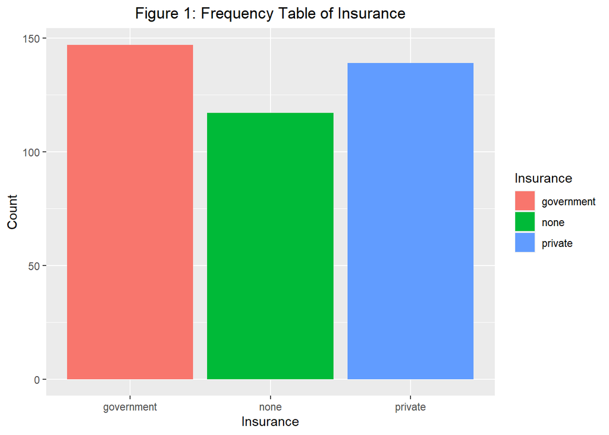

```r
# insert data visualization code here

# Figure 1: Frequency table of insurance variable
ggplot(data = diabetes) + aes(x=insurance, fill=insurance) + geom_bar() + labs(title="Figure 1: Frequency Table of Insurance", x="Insurance", y="Count", fill = "Insurance") + theme(plot.title = element_text(hjust = 0.5))
```

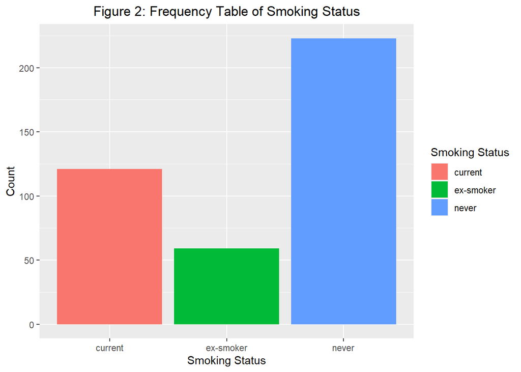

```r
# Figure 2: Frequency table of smoking variable
ggplot(data = diabetes) + aes(x=smoking, fill=smoking) + geom_bar() + labs(title="Figure 2: Frequency Table of Smoking Status", x="Smoking Status", y="Count", fill = "Smoking Status") + theme(plot.title = element_text(hjust = 0.5))
```

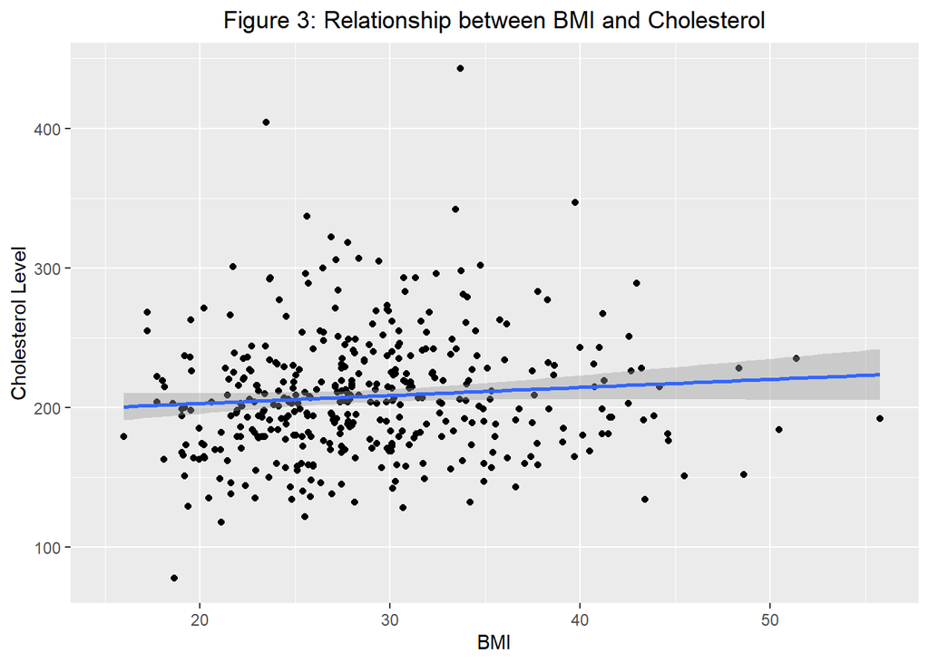

```r
# Figure 3: Scatter plot between BMI and Cholesterol
ggplot(data = diabetes) + aes(x=BMI, y=chol) +geom_point() + geom_smooth(method=lm) + labs(title="Figure 3: Relationship between BMI and Cholesterol", x="BMI", y="Cholesterol Level") + theme(plot.title = element_text(hjust = 0.5))
```

```r
# Correlation Coefficient
cor.test(diabetes$BMI, diabetes$chol, method="pearson", conf.level=0.95)
```

```
##
##  Pearson's product-moment correlation
##
## data:  diabetes$BMI and diabetes$chol
## t = 1.712, df = 394, p-value = 0.08768
## alternative hypothesis: true correlation is not equal to 0
## 95 percent confidence interval:
##  -0.01272251  0.18292861
## sample estimates:
##        cor
## 0.08593146
```

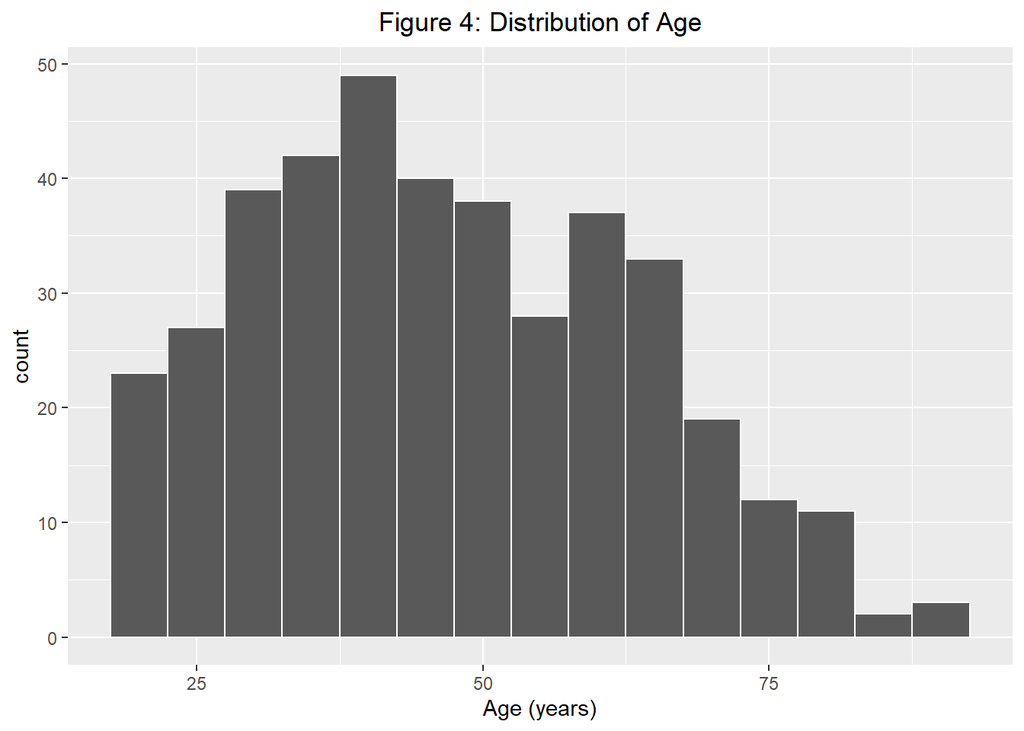

```r
# Figure 4: Histogram of Age
ggplot(data = diabetes) + aes(age) + geom_histogram(color="white", binwidth = 5) + labs(title="Figure 4: Distribution of Age", x="Age (years)") + theme(plot.title = element_text(hjust = 0.5))
```

## Logistic Regression Results

A 1 year increase in age causes the log odds of having diabetes to increase by 0.055454, holding the other independent variables constant. A 1 unit increase in BMI causes the log odds of having diabetes to increase by 0.073879, holding the other independent variables constant. A change in gender from someone who is female to male increases the natural log of the odds of having diabetes by 0.244852, holding the other independent variables constant.

```r
# insert logistic regression code
fit <- glm(dm ~ age + factor(gender) + BMI, data = diabetes, family = "binomial")

summary(fit)
```

[output not shown]